# Text Prediction App Milestone Report

Daniel Hertenstein

February 10, 2017

## Getting and Loading the Data

The data sets were downloaded from the course website and loaded into R using the readLines method. The data was then transformed into a corpus using the quanteda package to facilitate text mining operations. The two data sets used in this report correspond to text from real news articles and real tweets. The large size of the data files, ~200MB each, make for an extensive sample of how the English language is used in everyday life, and provide good training data for a prediction model.

```r
library(quanteda)

news <- readLines(file("Coursera-SwiftKey/final/en_US/en_US.news.txt", "rb"), skipNul = TRUE, encoding = "UTF-8")
closeAllConnections()

twitter <- readLines(file("Coursera-SwiftKey/final/en_US/en_US.twitter.txt", "rb"), skipNul = TRUE, encoding = "UTF-8")
closeAllConnections()

my_corpus <- corpus(news_sentences) + corpus(twitter_sentences)
```

## Summary Statistics and Interesting Findings

The news text file contains 1,010,242 lines, 1,993,065 sentences, and 40,950,892 words, while the twitter text file contains 2,360,148 lines, 3,763,082 sentences, and 37,005,141 words. The plots below show the percentage of all word occurrences covered by the most frequent words. 90% of all word occurrences in the news data test come from the 8,823 most freqent words, only 2.7% of the total 330,446 unique words. For the twitter data set, 90% of all word occurrences come from 1.4% of the total (5,503 of 389,314 unique words).

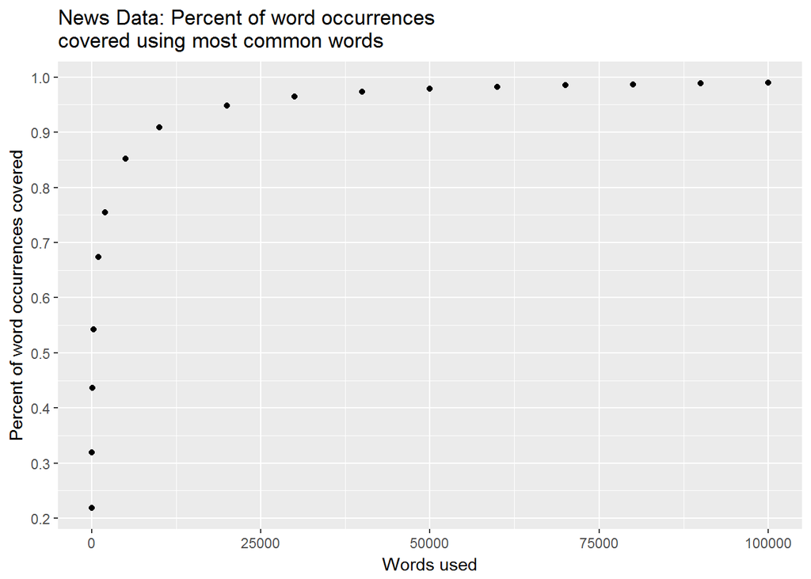

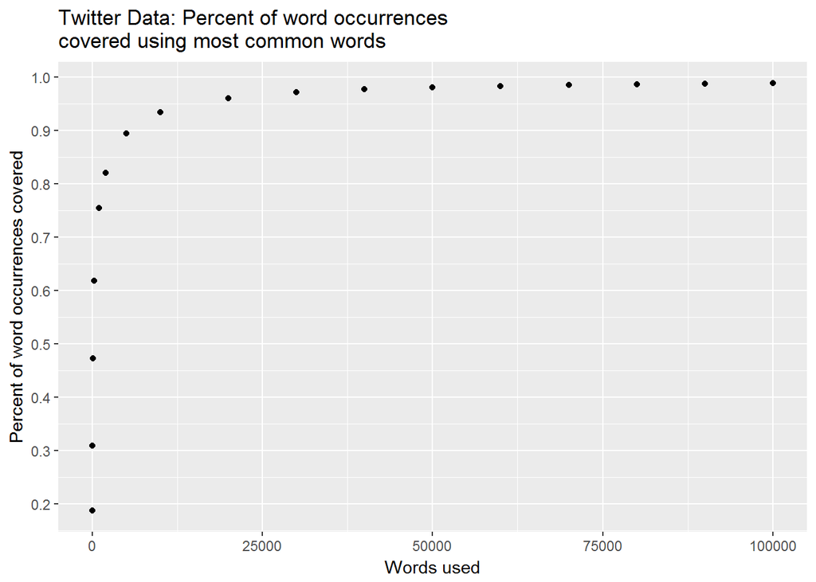

## Plan for Prediction Algorithm and Shiny App

The plan for the prediction algorithm centers around using only the list of 4-grams. We will creating a data frame of all of the 4-grams, containing five columns. The first four columns will be each of the words of each 4-gram, and the fifth coulmn will be number of times the particular 4-gram occurrs in the data set. Using a data frame of 4-grams, we can predict the next word when given a trigram, bigram, or unigram. The process will be the same for each. Extract all of the rows in the data frame that starts with the given N-gram. Order the rows by the value in the occurrences column and select the first row. Whatever word completes the phrase in the selected row will be the prediction. Below is the likely structure of the data frame.

```r
head(combos)
```

```
##       X1     X2    X3         X4 value
## 1     he wasn't  home      alone     1
## 2 wasn't   home alone apparently     1
## 3    the     st louis      plant     1
## 4     st  louis plant        had     1
## 5  louis  plant   had         to     1
## 6  plant    had    to      close     1
```

The plan for the app will be relatively straightforward. Before the user is able to do antyhing, the data frame of 4-grams will be loaded into memory. Then the user will be presented with a text box that they can enter any string into. Upon hitting a submit button, we will extract the last three words of the input phrase and use them to predict the next word using the above algorithm. We will then print the prediction out to the screen for the user to see.

## Thoughts Moving Forward

The final problem I can see is dealing with uknown N-grams; how to deal with a user input phrase that is not seen in the data frame. This will definitely be a problem given the size constraints of the data frame. I have seen potential solutions to this like backoff and discounting algorithms, so I will need to implement and test them in order to select one.